# Moon's rock segmentation using Artificial Lunar Landscape Dataset

This project aims to show that artificialy generated data can be very useful to train Neural Networks for real-life tasks such as Rock Segmentation and detection.

The dataset used for this project was created by [Romain PESSIA](https://www.kaggle.com/romainpessia) in an attempt to compensate the lack of such data in the field of space robotics.

I personally thank him for setting this data public.

```python
import os
os.environ['CUDA_VISIBLE_DEVICES'] = '-1'
#Libraries
import pandas as pd
import numpy as np
import matplotlib.pyplot as plt
import seaborn as sns
import cv2
import os
import re
import math
from sklearn.model_selection import train_test_split
from keras.callbacks import ModelCheckpoint, TensorBoard
import keras as keras
from keras.optimizers import Adam
import tensorflow as tf

#Local files
from modules.utility_functions import get_size
from modules.data.dataManipulation import adjustData, predictionToMask, imageGenerator, withoutGTtestGenerator, saveResult
from modules.models.unet import unet, jacard_coef_loss

#Model import
import segmentation_models as sm
```

```
Segmentation Models: using `keras` framework.
```

## Data Visualization

We will first introduce the data and try, then, to come up with a model that is able to predict rocks from a real Lunar picture.

There are two important folders of data:

- "clean" that contains the cleaned ground-truth of the rocks, ground and sky positions
- "render" that contains the input images

Let's load them in a pandas dataframe.

```python
DATA_PATH = "../Data/images"

RELATIVE_GT_FOLDER = "clean"
RELATIVE_IMAGES_FOLDER = "render"

RELATIVE_TEST_FOLDER = "test/render/render"
RELATIVE_RESULT_FOLDER = "test/results"

RELATIVE_VALIDATION_GT_FOLDER = "validation/clean"
RELATIVE_VALIDATION_IMAGES_FOLDER = "validation/render"

SEED = 42
NUM_CLASS = 4
FPN_IMAGE_SIZE = (256, 256)
```

```python
clean_ground_truth_paths = []
clean_base_images_paths = []

#First loading the path of all ground truth images
for root, dirs, files in os.walk(os.path.join(DATA_PATH, RELATIVE_GT_FOLDER+"/clean")):
    files_with_root = map(lambda file: os.path.join(root, file), files)
    masks_paths = pd.Series(files_with_root)
    break

#Then loading the path of all the images
for root, dirs, files in os.walk(os.path.join(DATA_PATH, RELATIVE_IMAGES_FOLDER+"/render")):
    files_with_root = map(lambda file: os.path.join(root, file), files)
    images_paths = pd.Series(files_with_root)
    break

print("There is a total of {} masks and {} images for a size of {}GB.".format(
    masks_paths.size,
    images_paths.size,
    round(get_size(os.path.join(os.getcwd(), DATA_PATH))/2**30, 2)))
print("The 400th mask and image are respectively named:\n - (mask){}\n - (img) {}".format(masks_paths[399], images_paths[399]))
```

```
There is a total of 6999 masks and 6999 images for a size of 5.09GB.
The 400th mask and image are respectively named:
 - (mask)../Data/images\clean/clean\clean0400.png
 - (img) ../Data/images\render/render\render0400.png
```

The number of images and masks seem to be matching as well as their name description using a common integer ID. Let's check if every mask has a matching image using their IDs. For this, we will use the ID contained in filenames as the index of the pandas Series and then merge them.

```python
masks_paths.index = masks_paths.apply(lambda file_name: re.sub('[^0-9]','', file_name))
images_paths.index = images_paths.apply(lambda file_name: re.sub('[^0-9]','', file_name))

merged_df = pd.concat([masks_paths, images_paths], axis=1)
```

If both series are equal, then the merge should have created as many rows as training examples with each two columns.

```python
print(merged_df.shape)
```

```
(6999, 2)
```

Let's now visualize data:

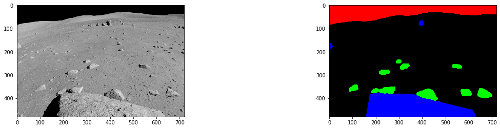

```python
row = merged_df.iloc[401,:]
image_data, mask_data = cv2.cvtColor(cv2.imread(row[1]),cv2.COLOR_BGR2RGB), cv2.cvtColor(cv2.imread(row[0]),cv2.COLOR_BGR2RGB)

f, axarr = plt.subplots(1,2)
f.set_figwidth(20)
axarr[0].imshow(image_data)
axarr[1].imshow(mask_data)
```

We can here see that each masks has 4 different segmenting colors for each 4 classes:

- Large rocks: here in blue
- smaller rocks (in green)
- sky: here in red
- rest (black)

# Creating training, validation and test sets

It is now time to create our training, validation and test sets for this problem. We will then focus on the model.

```python
from tensorflow.compat.v1 import ConfigProto
from tensorflow.compat.v1 import InteractiveSession

config = ConfigProto()
config.gpu_options.allow_growth = True
keras.backend.session = InteractiveSession(config=config)
```

```python
data_gen_args = dict(rotation_range=0.2,
                    width_shift_range=0.05,
                    height_shift_range=0.05,
                    shear_range=0.05,
                    zoom_range=0.05,
                    horizontal_flip=True,
                    fill_mode='nearest')

trainGene = imageGenerator(
    1,
    DATA_PATH,
    RELATIVE_IMAGES_FOLDER,
    RELATIVE_GT_FOLDER,
    data_gen_args,
    image_color_mode='rgb',
    mask_color_mode='rgb',
    num_class=NUM_CLASS,
    target_size=FPN_IMAGE_SIZE,
    flag_multi_class = True)

valGene = imageGenerator(
    1,
    DATA_PATH,
    RELATIVE_VALIDATION_IMAGES_FOLDER,
    RELATIVE_VALIDATION_GT_FOLDER,
    data_gen_args,
    image_color_mode='rgb',
    mask_color_mode='rgb',
    num_class=NUM_CLASS,
    target_size=FPN_IMAGE_SIZE,
    flag_multi_class = True)
```

```python
from datetime import datetime
now = datetime.now()
dir_name = now.strftime("%d_%m_%Y_%H_%M_%S")

os.mkdir(os.path.join('weights', dir_name))

model_filename = 'fpn_moon_seg_{epoch:02d}.hdf5'
model_save_weight_path = os.path.join(os.path.join('weights', dir_name), model_filename)
```

```python
# Segmentation models losses can be combined together by '+' and scaled by integer or float factor
# set class weights for dice_loss (car: 1.; pedestrian: 2.; background: 0.5;)
dice_loss = sm.losses.DiceLoss(class_weights=np.array([0.5, 2, 1, 0.5]))
focal_loss = sm.losses.BinaryFocalLoss() if NUM_CLASS == 1 else sm.losses.CategoricalFocalLoss()
total_loss = dice_loss + (1 * focal_loss)

# actulally total_loss can be imported directly from library, above example just show you how to manipulate with losses
# total_loss = sm.losses.binary_focal_dice_loss # or sm.losses.categorical_focal_dice_loss

metrics = [sm.metrics.IOUScore(threshold=0.5), sm.metrics.FScore(threshold=0.5)]
```

```python
with tf.device('/cpu:0'):
    model = sm.FPN(backbone_name="vgg16", input_shape=FPN_IMAGE_SIZE+(3,), classes=NUM_CLASS, activation="softmax", encoder_weights='imagenet')
    #model.load_weights("weights/12_10_2019_16_17_45/unet_moon_seg_17.hdf5")

    callbacks = [
        ModelCheckpoint(model_save_weight_path, monitor='loss',verbose=1, save_best_only=True),
        TensorBoard(log_dir='.', histogram_freq=1, write_graph=True, write_grads=False, write_images=True, embeddings_freq=0, embeddings_layer_names=None, embeddings_metadata=None, embeddings_data=None, update_freq='epoch'),
    ]

    model.compile(optimizer = Adam(lr=7e-4, epsilon=1e-8, decay=1e-6), loss=total_loss, metrics=metrics)

    model.fit_generator(
        trainGene,
        #validation_data=valGene,
        #validation_steps=2000,
        verbose=1,
        steps_per_epoch=2000,
        epochs=20,
        callbacks=callbacks)
```

```
Found 6999 images belonging to 1 classes.
Found 6999 images belonging to 1 classes.

Epoch 00001: loss improved from inf to 0.61310, saving model to weights\13_10_2019_21_35_44\fpn_moon_seg_01.hdf5

Epoch 00002: loss improved from 0.61310 to 0.52958, saving model to weights\13_10_2019_21_35_44\fpn_moon_seg_02.hdf5

Epoch 00003: loss improved from 0.52958 to 0.50110, saving model to weights\13_10_2019_21_35_44\fpn_moon_seg_03.hdf5

Epoch 00004: loss improved from 0.50110 to 0.47199, saving model to weights\13_10_2019_21_35_44\fpn_moon_seg_04.hdf5

Epoch 00005: loss improved from 0.47199 to 0.45325, saving model to weights\13_10_2019_21_35_44\fpn_moon_seg_05.hdf5

Epoch 00006: loss improved from 0.45325 to 0.45205, saving model to weights\13_10_2019_21_35_44\fpn_moon_seg_06.hdf5

Epoch 00007: loss improved from 0.45205 to 0.43955, saving model to weights\13_10_2019_21_35_44\fpn_moon_seg_07.hdf5

Epoch 00008: loss improved from 0.43955 to 0.42949, saving model to weights\13_10_2019_21_35_44\fpn_moon_seg_08.hdf5

Epoch 00009: loss improved from 0.42949 to 0.42568, saving model to weights\13_10_2019_21_35_44\fpn_moon_seg_09.hdf5

Epoch 00010: loss improved from 0.42568 to 0.41445, saving model to weights\13_10_2019_21_35_44\fpn_moon_seg_10.hdf5

Epoch 00011: loss improved from 0.41445 to 0.39935, saving model to weights\13_10_2019_21_35_44\fpn_moon_seg_11.hdf5

Epoch 00012: loss did not improve from 0.39935

Epoch 00013: loss did not improve from 0.39935

Epoch 00014: loss improved from 0.39935 to 0.39861, saving model to weights\13_10_2019_21_35_44\fpn_moon_seg_14.hdf5

Epoch 00015: loss did not improve from 0.39861

Epoch 00016: loss improved from 0.39861 to 0.39041, saving model to weights\13_10_2019_21_35_44\fpn_moon_seg_16.hdf5

Epoch 00017: loss improved from 0.39041 to 0.38539, saving model to weights\13_10_2019_21_35_44\fpn_moon_seg_17.hdf5

Epoch 00018: loss did not improve from 0.38539

Epoch 00019: loss improved from 0.38539 to 0.37983, saving model to weights\13_10_2019_21_35_44\fpn_moon_seg_19.hdf5

Epoch 00020: loss did not improve from 0.37983
```

```python
testGene = withoutGTtestGenerator(
    os.path.join(DATA_PATH, RELATIVE_TEST_FOLDER),
    #to_save_source_images_path=os.path.join(DATA_PATH, RELATIVE_RESULT_FOLDER),
    target_size=FPN_IMAGE_SIZE,
    flag_multi_class=True,
    as_gray=False)

model = sm.FPN(backbone_name="vgg16", input_shape=FPN_IMAGE_SIZE+(3,), classes=NUM_CLASS, activation="softmax", encoder_weights='imagenet')
model.load_weights("weights/13_10_2019_21_35_44/fpn_moon_seg_19.hdf5")
results = model.predict_generator(testGene,30,verbose=1)
saveResult(os.path.join(DATA_PATH, RELATIVE_RESULT_FOLDER), results,flag_multi_class=True,num_class=NUM_CLASS, to_resize_shape=(720,480))
```

[output not shown]